# Part II - Communicate Data Findings Project - Ford GoBike Slides

## Dataset Overview

> The dataset includes information about 183412 individual rides made in a bike-sharing system covering the greater San Francisco Bay area. The exploration exercise is focused on the distance covered by each person, and how this may be dependent on/closely related with other features such as age, gender, bike id, user type, day of the week

## Trip Duration and other quantitative variables

> Younger people (20 - 40 years) are more likely to ride a bike for longer minutes than older people. People who start a bike ride in the early hours of the morning (0hrs - 5hrs), are more likely to ride for a shorter period of time compared tho those who start after 10:00am. Those who rode their bikes for longer seconds were more likely to be using a more modern bike version. The bikers moved at different speeds, they could have ridden for 1000 seconds and traveled 5km, or just 1km.

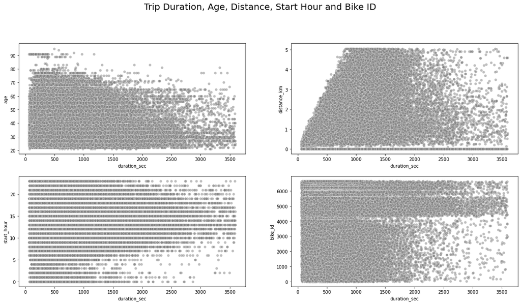

## Bike Usage for the Ambitious Bikers

> Interestingly, the ambitious bikers are mostly between their mid 20s and 40s. The people who rode the farthest are in their 30s People who start a bike ride in the early hours of the morning (0hrs-5hrs), are more likely to ride for a shorter period of time compared tho those who start after 10:00am. Those who rode their bikes for longer seconds were more likely to be using a more modern bike version (between bike_id 4200-7000). Most of the bikers who traveled far, traveled fast.

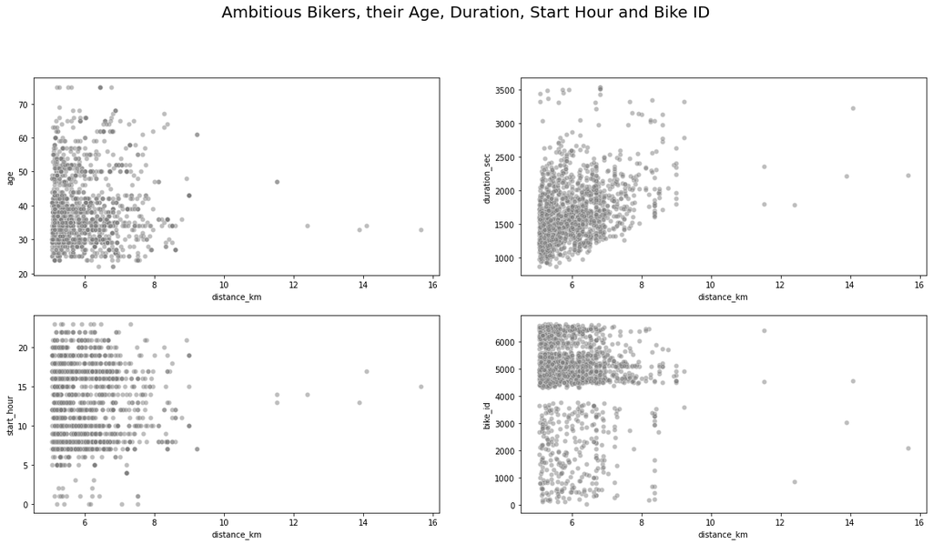

## Trip Distance, Gender, and Age

> Across all genders, older people tend to ride for shorter distances. More people from the `Other` gender category cycle for shorter distances.

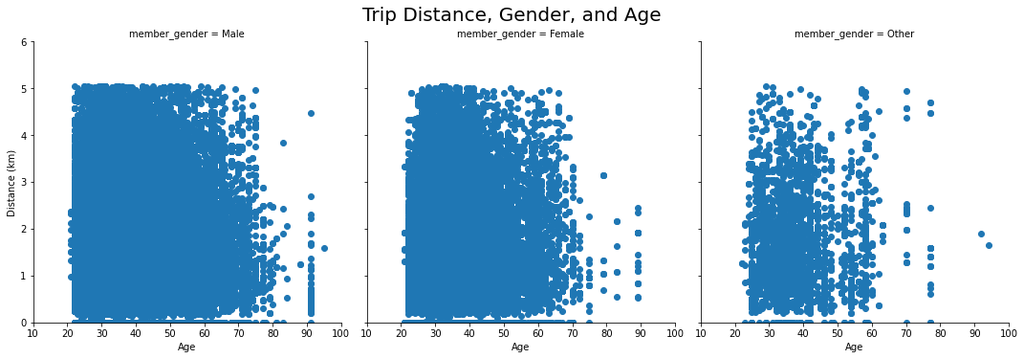